# Arine_technical_assessment

```python
import numpy as np
import pandas as pd
import warnings
from IPython.display import display, HTML
display(HTML("<style>.container { width:80% !important; }</style>"))
warnings.filterwarnings('ignore')
df_ad = pd.read_csv('/home/polabs2/Code/Arine/admissions.csv')
print(df_ad.columns)
df_ad['admit_date_new'] = pd.to_datetime(df_ad['admit_date'])

from pandas_profiling import ProfileReport
warnings.filterwarnings('ignore')
profile = ProfileReport(df_ad, title="Profiling Report")
profile
```

```
Index(['claim_number', 'patient_id', 'admit_date', 'discharge_date',
       'length_of_stay', 'primary_diagnosis', 'claimlinestatuscode',
       'type_of_bill', 'source_file'],
      dtype='object')
```

[interactive chart not shown]

```python
%matplotlib inline
from matplotlib import pyplot
df_ad['admit_date_new'] = pd.to_datetime(df_ad['admit_date'])
df_timeline = df_ad.groupby(['claim_number'], as_index=False).agg({'patient_id':'first', 'admit_date_new':'first'}).sort_values(by=['admit_date_new'])
df_timeline['month_year'] = pd.to_datetime(df_timeline['admit_date_new']).dt.to_period('M')
df_timeline = df_timeline.groupby(['month_year'], as_index=False).agg({'patient_id':'count'}) # pd.Series.nunique
df_timeline
```

|  | month_year | patient_id |
| --- | --- | --- |
| 0 | 2019-01 | 17631 |
| 1 | 2019-02 | 15776 |
| 2 | 2019-03 | 17367 |
| 3 | 2019-04 | 17026 |
| 4 | 2019-05 | 17442 |
| 5 | 2019-06 | 16902 |
| 6 | 2019-07 | 17244 |
| 7 | 2019-08 | 16992 |
| 8 | 2019-09 | 16673 |
| 9 | 2019-10 | 17286 |
| 10 | 2019-11 | 16765 |
| 11 | 2019-12 | 17224 |
| 12 | 2020-01 | 17358 |
| 13 | 2020-02 | 16518 |
| 14 | 2020-03 | 16027 |
| 15 | 2020-04 | 11044 |
| 16 | 2020-05 | 12252 |
| 17 | 2020-06 | 14180 |

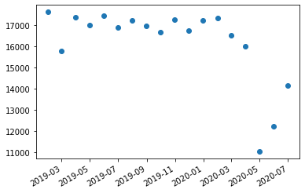

```python
import matplotlib.dates as mdates
import matplotlib.pyplot as plt
df_timeline.set_index('month_year')
plt.plot_date(df_timeline['month_year'], df_timeline['patient_id'])
plt.gcf().autofmt_xdate()
plt.show()
```

## Part A: We see a clear drop off in inpatient admissions starting in April 2020

### Many individuals stopped receiving inpatient or in person medical treatment during the COVID-19 first wave. They might have chosen to remain at home and 'tough it out' rather than seek help and risk exposure during that time. Studies in the UK have shown that the medical burden from missed elective surgeries and increased mental health issues due to isolation actually outweighted the COVID-19 burden in the longterm. Additionally, distrust of the medical community was at an all time high during this time, possibly even more so with anxious or paranoid patients.

```python
df_pds = pd.read_csv('/home/polabs2/Code/Arine/patient_diagnosis_summary.csv')
print(df_pds.columns)

from pandas_profiling import ProfileReport
warnings.filterwarnings('ignore')
profile = ProfileReport(df_pds, title="Profiling Report")
profile
```

```
Index(['patient_id', 'plan_name', 'medication_adherent', 'asthma',
       'hypertension', 'ocd', 'aids_hiv', 'implulse_disorder',
       'eating_disorder', 'amnestic_disorder', 'adhd', 'diabetes',
       'suicide_attempt', 'alcohol_use_disorder', 'opioid_use_disorder',
       'other_drug_related_use_disorder', 'dementia', 'delirium',
       'anxiety_disorders', 'stress_disorder', 'sleep_disorder',
       'personality_disorder'],
      dtype='object')
```

[interactive chart not shown]

```python
df2 = df_ad.groupby(['claim_number'], as_index=False).agg({'patient_id':'first', 'admit_date_new':'first', 'length_of_stay':'first', 'primary_diagnosis':'first'
                                                                  }).sort_values(by=['patient_id','admit_date_new'])
df2.head(5)
```

|  | claim_number | patient_id | admit_date_new | length_of_stay | primary_diagnosis |
| --- | --- | --- | --- | --- | --- |
| 193502 | 193502 | 00013db5-d761-4c65-ad6d-e9d6aade10d4 | 2019-08-22 | 0 | F325 |
| 193501 | 193501 | 00013db5-d761-4c65-ad6d-e9d6aade10d4 | 2019-10-08 | 4 | F4320 |
| 252582 | 252582 | 00013db5-d761-4c65-ad6d-e9d6aade10d4 | 2020-01-21 | 0 | F641 |
| 275253 | 275253 | 00013db5-d761-4c65-ad6d-e9d6aade10d4 | 2020-04-11 | 0 | F3132 |
| 241729 | 241729 | 00013db5-d761-4c65-ad6d-e9d6aade10d4 | 2020-06-04 | 1 | F3164 |

```python
df_pred = df2[df2['admit_date_new'] < '2019-07-01']
df_pred = df_pred.groupby(['patient_id'], as_index=False).agg(los_mean=('length_of_stay', np.mean), los_sum=('length_of_stay', np.sum)
                                                              , primary_diagnosis=('primary_diagnosis', 'first')
                                                              , admit_count=('admit_date_new', 'count'))
print(df_pred.shape)
df_pred.head(5)
```

```
(75033, 5)
```

|  | patient_id | los_mean | los_sum | primary_diagnosis | admit_count |
| --- | --- | --- | --- | --- | --- |
| 0 | 00022a60-c1d6-4a36-9952-b60da9c6a8c2 | 0.0 | 0 | F988 | 1 |
| 1 | 0002c5e8-a472-48db-8800-94b260a1cae6 | 0.0 | 0 | Z1231 | 1 |
| 2 | 0002f1dc-962f-41f9-bdf8-e80032a898f5 | 0.0 | 0 | F908 | 1 |
| 3 | 000402a8-47d3-4034-b063-537059ee7293 | 0.5 | 1 | F3160 | 2 |
| 4 | 0004d29a-5816-46b5-bddc-a9033e152313 | 3.0 | 3 | F1420 | 1 |

## B1

### I've grouped the admissions data patient and created variables for average length of stay, total length of stay, primary diagnosis at first admission and total admissions

### I wanted to capture some information about 'how often' someone was admitted as well as 'how severe' the admissions were, aka length of stay

```python
df_target = df2[df2['admit_date_new'] >= '2019-07-01']
df_target = df_target.groupby(['patient_id'], as_index=False).agg(admit_count=('admit_date_new', 'count'))
df_target['target'] = 0
df_target.loc[df_target['admit_count'] >= 2, 'target'] = 1

df_target = df_target.drop(['admit_count'], axis=1)
df_target.head(5)
```

|  | patient_id | target |
| --- | --- | --- |
| 0 | 00013db5-d761-4c65-ad6d-e9d6aade10d4 | 1 |
| 1 | 00022a60-c1d6-4a36-9952-b60da9c6a8c2 | 0 |
| 2 | 0002c5e8-a472-48db-8800-94b260a1cae6 | 1 |
| 3 | 0002f1dc-962f-41f9-bdf8-e80032a898f5 | 1 |
| 4 | 000402a8-47d3-4034-b063-537059ee7293 | 1 |

```python
cols = ['medication_adherent', 'asthma', 'hypertension', 'ocd', 'aids_hiv', 'implulse_disorder', 'eating_disorder', 'amnestic_disorder', 'adhd', 'diabetes', 'suicide_attempt', 'alcohol_use_disorder', 'opioid_use_disorder', 'other_drug_related_use_disorder', 'dementia', 'delirium', 'anxiety_disorders', 'stress_disorder', 'sleep_disorder', 'personality_disorder']
df_pds2[cols] = df_pds[cols].replace({True:1,False:0})
df_pds3 = pd.concat([df_pds['patient_id'], df_pds2], axis=1)
df_pred2 = pd.merge(df_pred, df_pds3, how='left', on='patient_id')
print(df_pred2.columns)
df_pred2.head(5)
```

```
Index(['patient_id', 'los_mean', 'los_sum', 'primary_diagnosis', 'admit_count',
       'medication_adherent', 'asthma', 'hypertension', 'ocd', 'aids_hiv',
       'implulse_disorder', 'eating_disorder', 'amnestic_disorder', 'adhd',
       'diabetes', 'suicide_attempt', 'alcohol_use_disorder',
       'opioid_use_disorder', 'other_drug_related_use_disorder', 'dementia',
       'delirium', 'anxiety_disorders', 'stress_disorder', 'sleep_disorder',
       'personality_disorder'],
      dtype='object')
```

|  | patient_id | los_mean | los_sum | primary_diagnosis | admit_count | medication_adherent | asthma | hypertension | ocd | aids_hiv | ... | suicide_attempt | alcohol_use_disorder | opioid_use_disorder | other_drug_related_use_disorder | dementia | delirium | anxiety_disorders | stress_disorder | sleep_disorder | personality_disorder |
| --- | --- | --- | --- | --- | --- | --- | --- | --- | --- | --- | --- | --- | --- | --- | --- | --- | --- | --- | --- | --- | --- |
| 0 | 00022a60-c1d6-4a36-9952-b60da9c6a8c2 | 0.0 | 0 | F988 | 1 | 1 | 1 | 0 | 0 | 0 | ... | 0 | 1 | 1 | 0 | 0 | 0 | 0 | 0 | 0 | 0 |
| 1 | 0002c5e8-a472-48db-8800-94b260a1cae6 | 0.0 | 0 | Z1231 | 1 | 1 | 1 | 0 | 0 | 0 | ... | 0 | 1 | 0 | 0 | 0 | 0 | 0 | 0 | 0 | 0 |
| 2 | 0002f1dc-962f-41f9-bdf8-e80032a898f5 | 0.0 | 0 | F908 | 1 | 1 | 0 | 0 | 0 | 0 | ... | 0 | 1 | 0 | 0 | 0 | 0 | 0 | 0 | 0 | 1 |
| 3 | 000402a8-47d3-4034-b063-537059ee7293 | 0.5 | 1 | F3160 | 2 | 1 | 1 | 0 | 1 | 0 | ... | 0 | 0 | 0 | 0 | 0 | 0 | 0 | 0 | 0 | 0 |
| 4 | 0004d29a-5816-46b5-bddc-a9033e152313 | 3.0 | 3 | F1420 | 1 | 1 | 1 | 0 | 0 | 1 | ... | 0 | 1 | 0 | 0 | 0 | 1 | 0 | 0 | 0 | 0 |

5 rows × 25 columns

```python
from collections import Counter
from sklearn import preprocessing
def cumulatively_categorise(column,threshold =.15,return_categories_list=True):
    #Find the threshold value using the percentage and number of instances in the column
    threshold_value=int(threshold*len(column))
    #Initialise an empty list for our new minimised categories
    categories_list=[]
    #Initialise a variable to calculate the sum of frequencies
    s=0
    #Create a counter dictionary of the form unique_value: frequency
    counts=Counter(column)

    #Loop through the category name and its corresponding frequency after sorting the categories by descending order of frequency
    for i,j in counts.most_common():
        #Add the frequency to the global sum
        s+=dict(counts)[i]
        #Append the category name to the list
        categories_list.append(i)
        #print(i)
        #Check if the global sum has reached the threshold value, if so break the loop
        if s>=threshold_value:
            break
        #Append the category Other to the list
        categories_list.append('Other')

    #Replace all instances not in our new categories by Other
    new_column=column.apply(lambda x: x if x in categories_list else 'Other')

    #Return transformed column and unique values if return_categories=True
    if(return_categories_list):
        #print(categories_list)
        return new_column,categories_list
    #Return only the transformed column if return_categories=False
    else:
        return new_column

enc = preprocessing.OneHotEncoder(handle_unknown='ignore')
transformed_column, transformed_columnnew_category_list=cumulatively_categorise(df_pred2['primary_diagnosis'], return_categories_list=True)
print(len(transformed_columnnew_category_list))

encs = pd.DataFrame(enc.fit_transform(pd.DataFrame(transformed_column)).toarray())
encs = encs.astype(int)
print(encs.shape)
encs.columns = enc.fit(pd.DataFrame(transformed_column)).get_feature_names_out()
print(encs.columns)
```

```
29
(75033, 16)
Index(['primary_diagnosis_F1021', 'primary_diagnosis_F3111',
       'primary_diagnosis_F329', 'primary_diagnosis_F333',
       'primary_diagnosis_F340', 'primary_diagnosis_F39',
       'primary_diagnosis_F430', 'primary_diagnosis_F4311',
       'primary_diagnosis_F4322', 'primary_diagnosis_F439',
       'primary_diagnosis_F5001', 'primary_diagnosis_F603',
       'primary_diagnosis_F902', 'primary_diagnosis_F909',
       'primary_diagnosis_F988', 'primary_diagnosis_Other'],
      dtype='object')
```

```python
#df_pred3 = pd.concat([df_pred2.reset_index(), encs.reset_index()], axis=1)
df_pred3 = df_pred2.drop(['primary_diagnosis'], axis=1)
print(len(df_pred3))
df_pred3.columns
```

```
75033
```

```
Index(['patient_id', 'los_mean', 'los_sum', 'admit_count',
       'medication_adherent', 'asthma', 'hypertension', 'ocd', 'aids_hiv',
       'implulse_disorder', 'eating_disorder', 'amnestic_disorder', 'adhd',
       'diabetes', 'suicide_attempt', 'alcohol_use_disorder',
       'opioid_use_disorder', 'other_drug_related_use_disorder', 'dementia',
       'delirium', 'anxiety_disorders', 'stress_disorder', 'sleep_disorder',
       'personality_disorder'],
      dtype='object')
```

```python
df_pred4 = pd.merge(df_pred3, df_target, how='left', on='patient_id')
df_pred4 = df_pred4.drop('patient_id', axis=1).dropna()
print(df_pred4['target'].mean())
print(len(df_pred4[df_pred4['target'] == 1]))
df_pred4
```

```
0.6657939754555597
44758
```

|  | los_mean | los_sum | admit_count | medication_adherent | asthma | hypertension | ocd | aids_hiv | implulse_disorder | eating_disorder | ... | alcohol_use_disorder | opioid_use_disorder | other_drug_related_use_disorder | dementia | delirium | anxiety_disorders | stress_disorder | sleep_disorder | personality_disorder | target |
| --- | --- | --- | --- | --- | --- | --- | --- | --- | --- | --- | --- | --- | --- | --- | --- | --- | --- | --- | --- | --- | --- |
| 0 | 0.0 | 0 | 1 | 1 | 1 | 0 | 0 | 0 | 0 | 1 | ... | 1 | 1 | 0 | 0 | 0 | 0 | 0 | 0 | 0 | 0.0 |
| 1 | 0.0 | 0 | 1 | 1 | 1 | 0 | 0 | 0 | 1 | 0 | ... | 1 | 0 | 0 | 0 | 0 | 0 | 0 | 0 | 0 | 1.0 |
| 2 | 0.0 | 0 | 1 | 1 | 0 | 0 | 0 | 0 | 1 | 0 | ... | 1 | 0 | 0 | 0 | 0 | 0 | 0 | 0 | 1 | 1.0 |
| 3 | 0.5 | 1 | 2 | 1 | 1 | 0 | 1 | 0 | 1 | 0 | ... | 0 | 0 | 0 | 0 | 0 | 0 | 0 | 0 | 0 | 1.0 |
| 4 | 3.0 | 3 | 1 | 1 | 1 | 0 | 0 | 1 | 1 | 0 | ... | 1 | 0 | 0 | 0 | 1 | 0 | 0 | 0 | 0 | 1.0 |
| ... | ... | ... | ... | ... | ... | ... | ... | ... | ... | ... | ... | ... | ... | ... | ... | ... | ... | ... | ... | ... | ... |
| 75028 | 0.0 | 0 | 1 | 1 | 1 | 0 | 0 | 0 | 0 | 0 | ... | 0 | 0 | 0 | 0 | 0 | 0 | 0 | 0 | 0 | 0.0 |
| 75029 | 1.0 | 2 | 2 | 1 | 0 | 0 | 0 | 0 | 1 | 0 | ... | 1 | 0 | 0 | 1 | 0 | 0 | 0 | 1 | 0 | 1.0 |
| 75030 | 2.0 | 4 | 2 | 1 | 0 | 0 | 1 | 0 | 1 | 0 | ... | 1 | 0 | 1 | 1 | 0 | 0 | 0 | 0 | 0 | 0.0 |
| 75031 | 0.0 | 0 | 1 | 1 | 0 | 0 | 1 | 0 | 0 | 1 | ... | 1 | 0 | 0 | 0 | 0 | 0 | 0 | 0 | 0 | 0.0 |
| 75032 | 0.0 | 0 | 1 | 1 | 1 | 0 | 0 | 1 | 0 | 1 | ... | 1 | 0 | 0 | 0 | 0 | 0 | 0 | 1 | 0 | 1.0 |

67225 rows × 24 columns

```python
df_pred4.to_csv('model_df.csv')
```

```python
df = df_pred4
from statsmodels.api import OLS
ols_model = OLS(df.target, df.drop('target', axis=1)).fit()
OLS(df.target, df.drop('target', axis=1)).fit().summary()
```

OLS Regression Results

| Dep. Variable: | target | R-squared (uncentered): | 0.662 |
| --- | --- | --- | --- |
| Model: | OLS | Adj. R-squared (uncentered): | 0.662 |
| Method: | Least Squares | F-statistic: | 5715. |
| Date: | Thu, 27 Oct 2022 | Prob (F-statistic): | 0.00 |
| Time: | 00:02:25 | Log-Likelihood: | -45286. |
| No. Observations: | 67225 | AIC: | 9.062e+04 |
| Df Residuals: | 67202 | BIC: | 9.083e+04 |
| Df Model: | 23 |  |  |
| Covariance Type: | nonrobust |  |  |

|  | coef | std err | t | P>\|t\| | [0.025 | 0.975] |
| --- | --- | --- | --- | --- | --- | --- |
| los_mean | 0.0161 | 0.003 | 4.679 | 0.000 | 0.009 | 0.023 |
| los_sum | -0.0126 | 0.003 | -4.254 | 0.000 | -0.018 | -0.007 |
| admit_count | 0.1012 | 0.005 | 20.243 | 0.000 | 0.091 | 0.111 |
| medication_adherent | 0.4997 | 0.007 | 67.137 | 0.000 | 0.485 | 0.514 |
| asthma | 0.0080 | 0.004 | 2.183 | 0.029 | 0.001 | 0.015 |
| hypertension | 0.0058 | 0.004 | 1.443 | 0.149 | -0.002 | 0.014 |
| ocd | 0.0030 | 0.004 | 0.714 | 0.475 | -0.005 | 0.011 |
| aids_hiv | 0.0054 | 0.004 | 1.279 | 0.201 | -0.003 | 0.014 |
| implulse_disorder | 0.0066 | 0.004 | 1.564 | 0.118 | -0.002 | 0.015 |
| eating_disorder | 0.0047 | 0.004 | 1.163 | 0.245 | -0.003 | 0.013 |
| amnestic_disorder | 0.0137 | 0.004 | 3.743 | 0.000 | 0.007 | 0.021 |
| adhd | 0.0058 | 0.004 | 1.449 | 0.147 | -0.002 | 0.014 |
| diabetes | 0.0071 | 0.004 | 1.781 | 0.075 | -0.001 | 0.015 |
| suicide_attempt | 0.0035 | 0.008 | 0.424 | 0.672 | -0.013 | 0.020 |
| alcohol_use_disorder | 0.0012 | 0.004 | 0.332 | 0.740 | -0.006 | 0.009 |
| opioid_use_disorder | 0.0156 | 0.005 | 3.045 | 0.002 | 0.006 | 0.026 |
| other_drug_related_use_disorder | 0.0018 | 0.006 | 0.292 | 0.770 | -0.010 | 0.014 |
| dementia | -0.0007 | 0.006 | -0.120 | 0.905 | -0.013 | 0.011 |
| delirium | 0.0113 | 0.008 | 1.346 | 0.178 | -0.005 | 0.028 |
| anxiety_disorders | 0.0014 | 0.006 | 0.236 | 0.813 | -0.010 | 0.013 |
| stress_disorder | 0.0089 | 0.004 | 2.097 | 0.036 | 0.001 | 0.017 |
| sleep_disorder | 0.0039 | 0.004 | 0.925 | 0.355 | -0.004 | 0.012 |
| personality_disorder | 0.0096 | 0.006 | 1.579 | 0.114 | -0.002 | 0.021 |

| Omnibus: | 436175.516 | Durbin-Watson: | 2.003 |
| --- | --- | --- | --- |
| Prob(Omnibus): | 0.000 | Jarque-Bera (JB): | 11387.069 |
| Skew: | -0.686 | Prob(JB): | 0.00 |
| Kurtosis: | 1.523 | Cond. No. | 20.7 |

Notes:  
[1] R² is computed without centering (uncentered) since the model does not contain a constant.  
[2] Standard Errors assume that the covariance matrix of the errors is correctly specified.

## B2 & B3

### ordinary least squares model

### m residuals: n - k - 1 aka: obs - vars - 1

### R squared how much of indepednent var is explained by cahnges in depedent variable 66.2%

### adj R squared, a version of above penlaizied for number of variables 66.2%

### f-stat likeklihood that our vars' effect is zero --- very low

#

### Prob (F-statistic): 0.00 <-- well below 0.05, closer to 0... we can reject the null hypothesius that our variables have no predictive power

#

### coefficients are value of intercept, negative is inverse relationship - ie positive coefficient + positive variable = assoc with increased risk

### P>|t| is p value, measure of how likely coefficient has no effect on outcome, <0.05 is signficant effect

```python
from sklearn.linear_model import LogisticRegressionCV
from sklearn.metrics import classification_report
from sklearn.preprocessing import StandardScaler
scaler = StandardScaler()
scaler = scaler.fit(df.drop(['target'], axis=1))
X = scaler.transform(df.drop(['target'], axis=1))
y = df['target']
clf_log = LogisticRegressionCV(cv=5, random_state=0).fit(X, y)
y_preds = clf_log.predict(X)
print(classification_report(y, y_preds))
```

```
              precision    recall  f1-score   support

         0.0       0.00      0.00      0.00     22467
         1.0       0.67      1.00      0.80     44758

    accuracy                           0.67     67225
   macro avg       0.33      0.50      0.40     67225
weighted avg       0.44      0.67      0.53     67225
```

```python
# random forrest model
from sklearn.model_selection import GridSearchCV
from sklearn.utils import shuffle
from sklearn.ensemble import RandomForestClassifier

df = shuffle(df, random_state=0)
from sklearn.utils import resample
# Separate majority and minority classes
df_majority = df[df.target==1]
df_minority = df[df.target==0]

df_minority_upsampled = resample(df_minority,
                                 replace=True,     # sample with replacement
                                 n_samples=44758,    # to match majority class
                                 random_state=123) # reproducible results
df_upsampled = pd.concat([df_majority, df_minority_upsampled])
print(df_upsampled.target.value_counts())
df = shuffle(df_upsampled, random_state=0)
print(df.shape)
```

[output not shown]

```python
x_train = df.drop(['target'], axis=1).iloc[0:75000,:]
scaler = StandardScaler()
scaler = scaler.fit(x_train)
x_train = scaler.transform(x_train)

x_test = df.drop(['target'], axis=1).iloc[75001:,:]
x_test = scaler.transform(x_test)
y_train = df.target.iloc[0:75000]
y_test = df.target.iloc[75001:]

parameters = {'max_depth':(8, 16, 24 ), 'criterion': ['gini', 'entropy']}
rfc = RandomForestClassifier(random_state=0, n_jobs=-1)
```

```python
print(x_train.shape)
print(x_test.shape)
print(y_train.shape)
print(y_test.shape)

clf = GridSearchCV(rfc, parameters)
clf.fit(x_train, y_train)

y_preds = clf.predict(x_test)
print(classification_report(y_test, y_preds))
print(clf.best_params_)
```

```
(75000, 41)
(14515, 41)
(75000,)
(14515,)
              precision    recall  f1-score   support

         0.0       0.78      0.84      0.81      7221
         1.0       0.83      0.76      0.79      7294

    accuracy                           0.80     14515
   macro avg       0.80      0.80      0.80     14515
weighted avg       0.80      0.80      0.80     14515

{'criterion': 'gini', 'max_depth': 24}
```

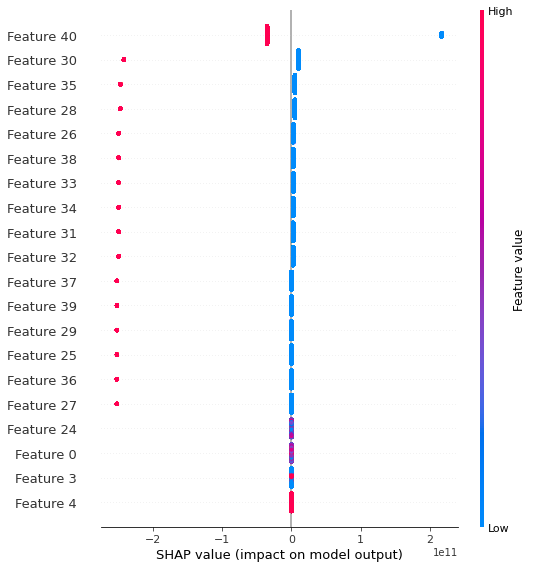

```python
import shap
from sklearn.linear_model import LinearRegression
shap.initjs()
model = LinearRegression()
model.fit(x_train, y_train)
explainer = shap.LinearExplainer(model, x_train)
shap_values = explainer.shap_values(x_train)
shap.summary_plot(shap_values, x_train)
```

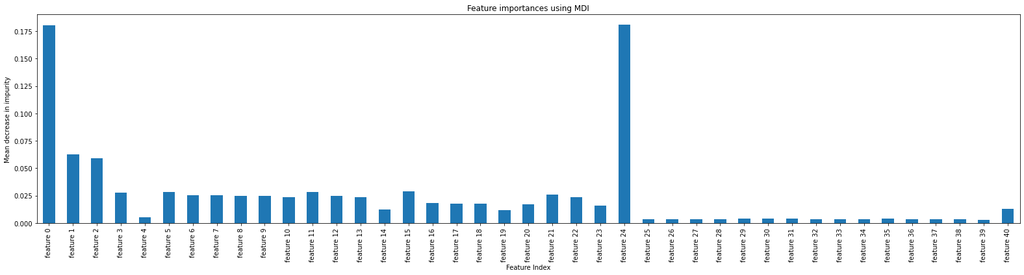

```python
%matplotlib inline
import matplotlib.pyplot as plt
from sklearn_evaluation import plot
feature_names = [f"feature {i}" for i in range(x_train.shape[1])]

importances = clf.best_estimator_.feature_importances_
forest_importances = pd.Series(importances, index=feature_names)

fig, ax = plt.subplots(figsize=(22,6))
forest_importances.plot.bar( ax=ax)
ax.set_title("Feature importances using MDI")
ax.set_ylabel("Mean decrease in impurity")
ax.set_xlabel("Feature Index")
fig.tight_layout()
```

## B4. The accuracy of the random forest model (80%) was much better than the OLS (33%).

### However, the RF model benefited for additional feature engineering and class balancing. Sparse feature engineering does work well with OLS models. With additional time I would further explore the diagnoses values in the admissions dataset as some codes seem to have a high degree of information gain as evidenced by the MDI and SHAP plots.

```python
y_preds = ols_model.predict( df.drop('target',axis=1))
print(classification_report(df.target.astype(int), y_preds.astype(int)))
print(clf.best_params_)
```

```
              precision    recall  f1-score   support

           0       0.33      1.00      0.50     22467
           1       1.00      0.00      0.00     44758

    accuracy                           0.33     67225
   macro avg       0.67      0.50      0.25     67225
weighted avg       0.78      0.33      0.17     67225

{'criterion': 'gini', 'max_depth': 24}
```